# CEMACS Experiment Daily Report

Yusri Yusup, PhD

## Air-sea flux exchanges and weather

Date: 2022-04-16

## CO<sub>2</sub> flux

This plots shows the vertical movement or fluxes of carbon dioxide (CO<sub>2</sub>) from the water and land surfaces surrounding the station.

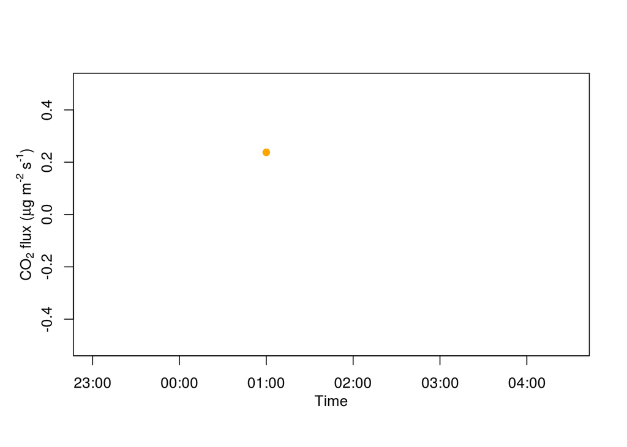

## CO<sub>2</sub> footprint

Location of sources CO<sub>2</sub> flux (90% contribution) using footprint analysis. Note that ‘wind_strict_check’ is off so sources could be from non-oceanic sources. Values in legend is in ug m[-2] s[-1].

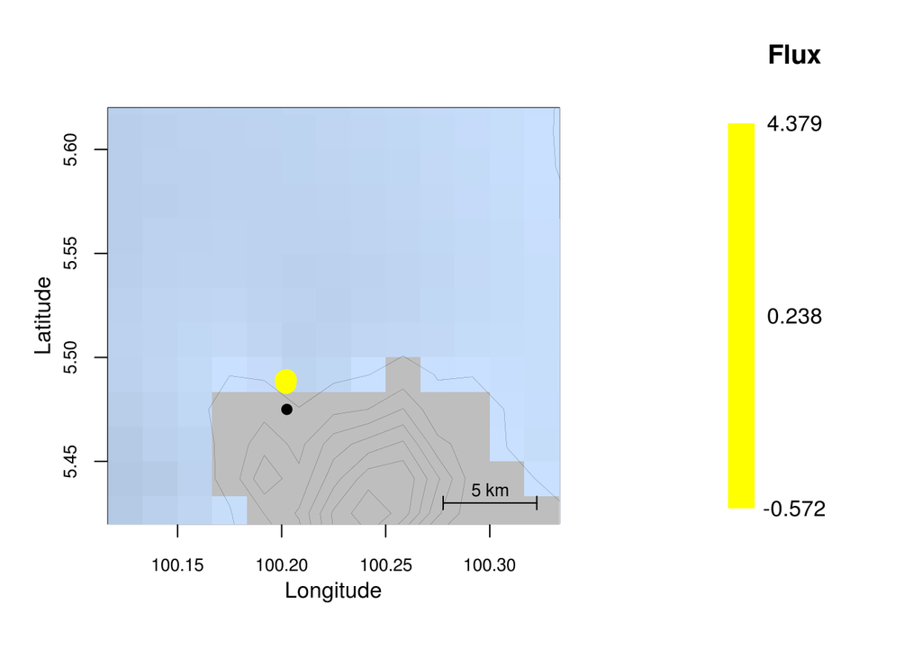

## Latent heat (LE)

This plots shows the vertical movement of moisture or latent heat (LE) from the water and land surfaces surrounding the station.

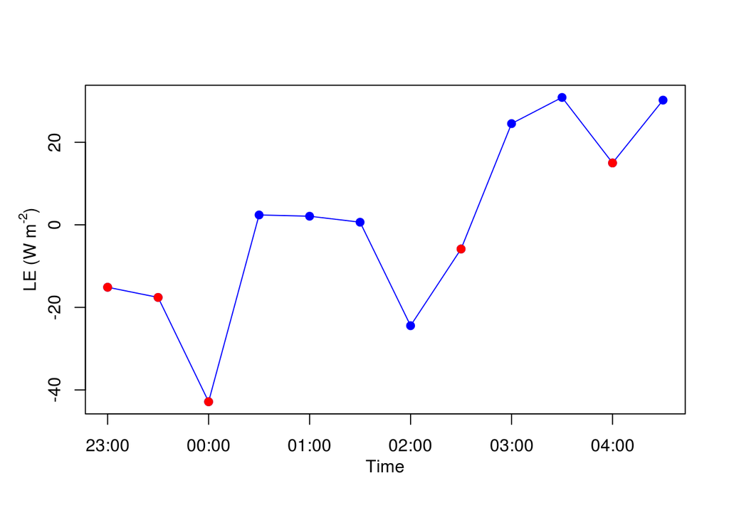

## Sensible heat (H)

This plots shows the vertical movement or fluxes of dry heat or sensible heat (H) from the water and land surfaces surrounding the station.

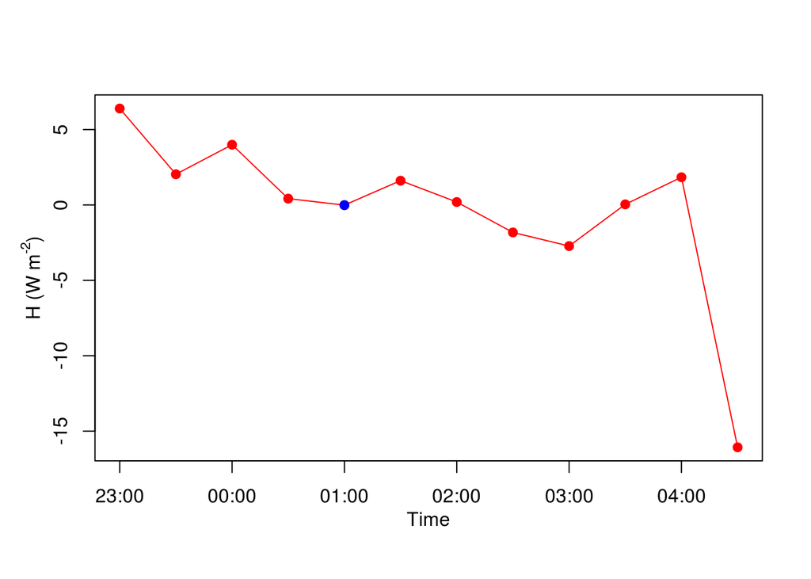

## Global and net radiation

Global radiation (RG) is red and net radiation (RN) is orange.

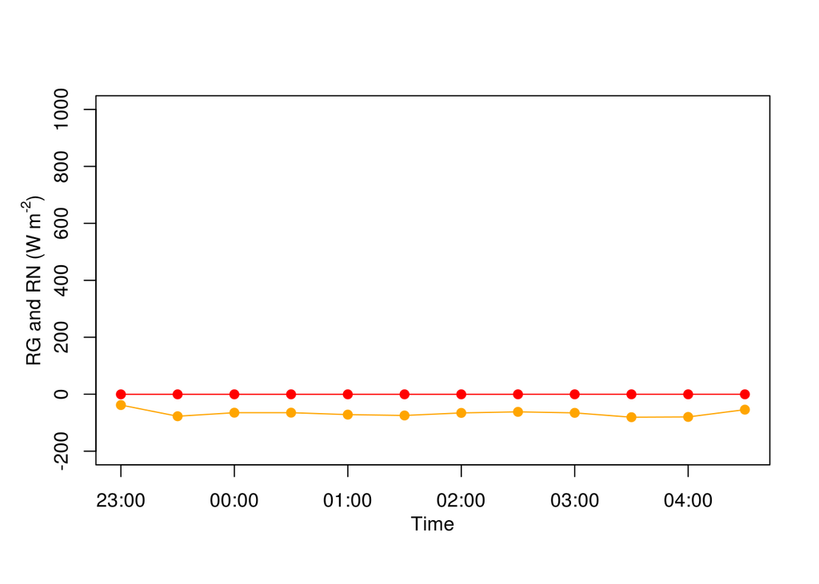

## Photosynthetic active radiation

Photosynthetic active radiation (PAR)

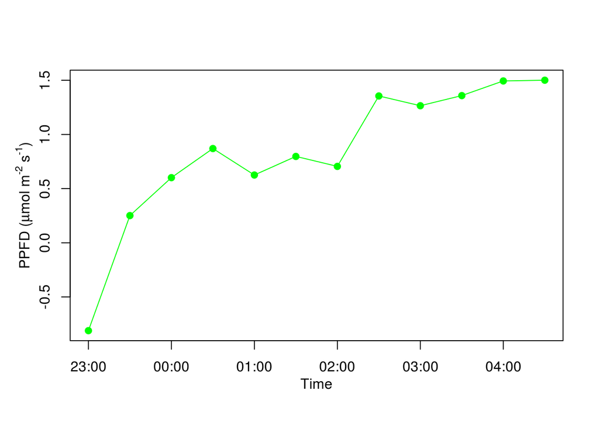

## Wind Speed (WS)

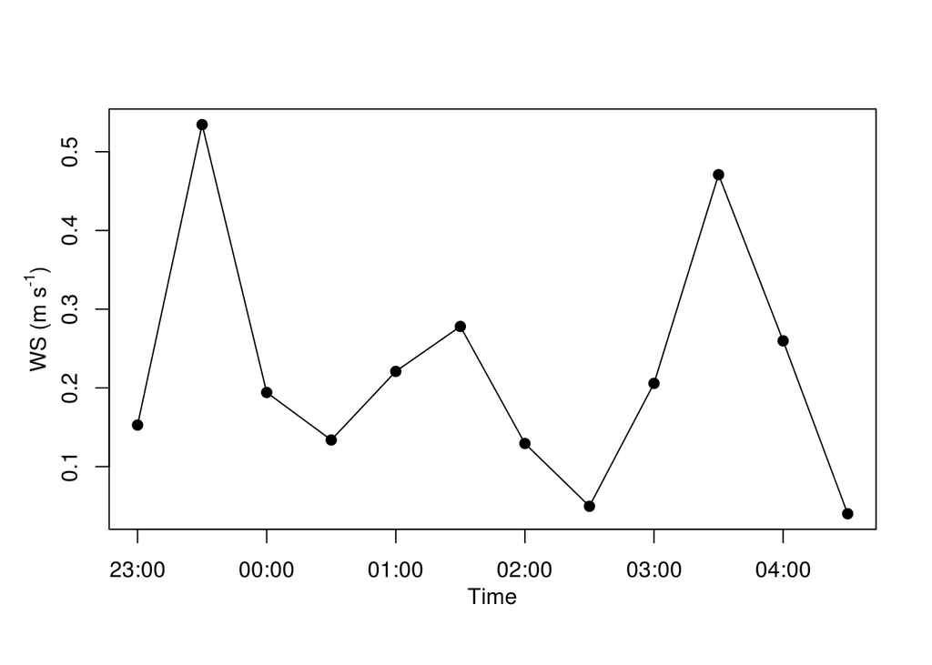

## Wind Direction (WD)

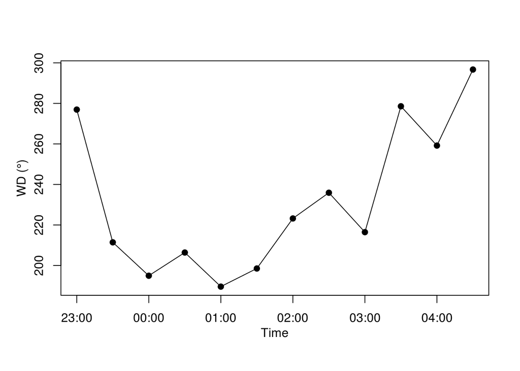

## Wind rose

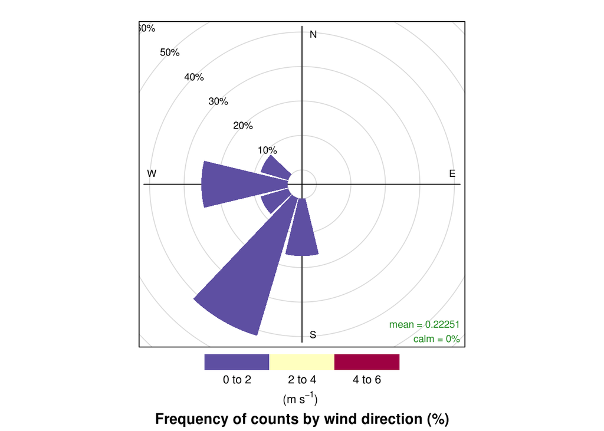

## Atmospheric temperature (T)

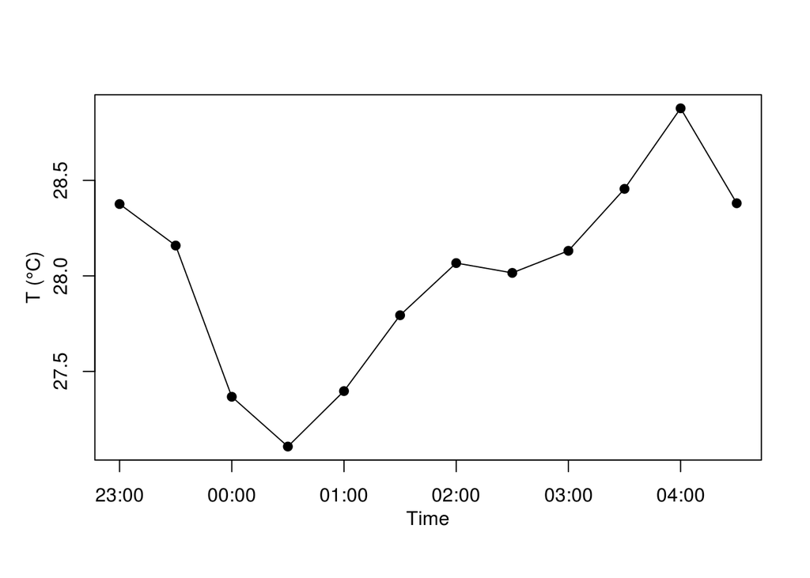

## Relative Humidity (RH)

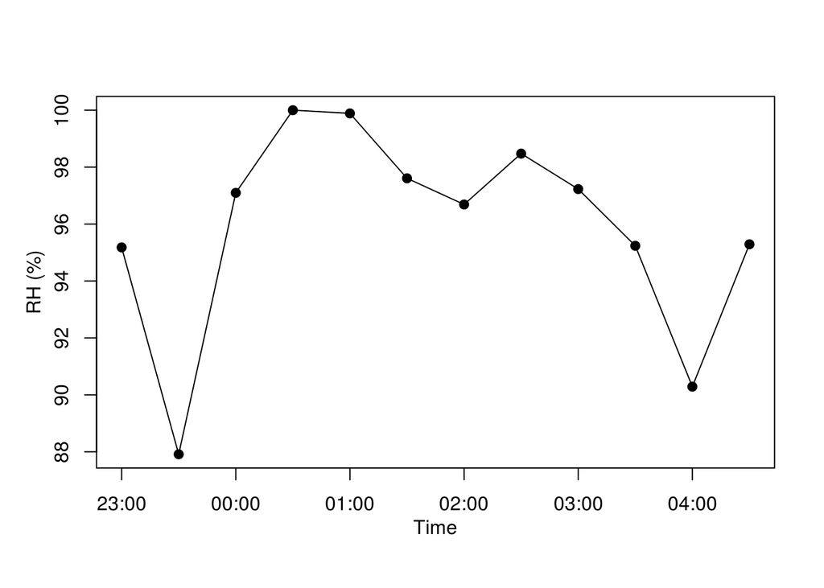

## Underwater temperature (T)

Underwater temperature (T) in degree celsius near the surface of the water (dark blue). The temperature at the surface would dip to cool temperatures due to low tide which causes the sensor to be above the water surface.

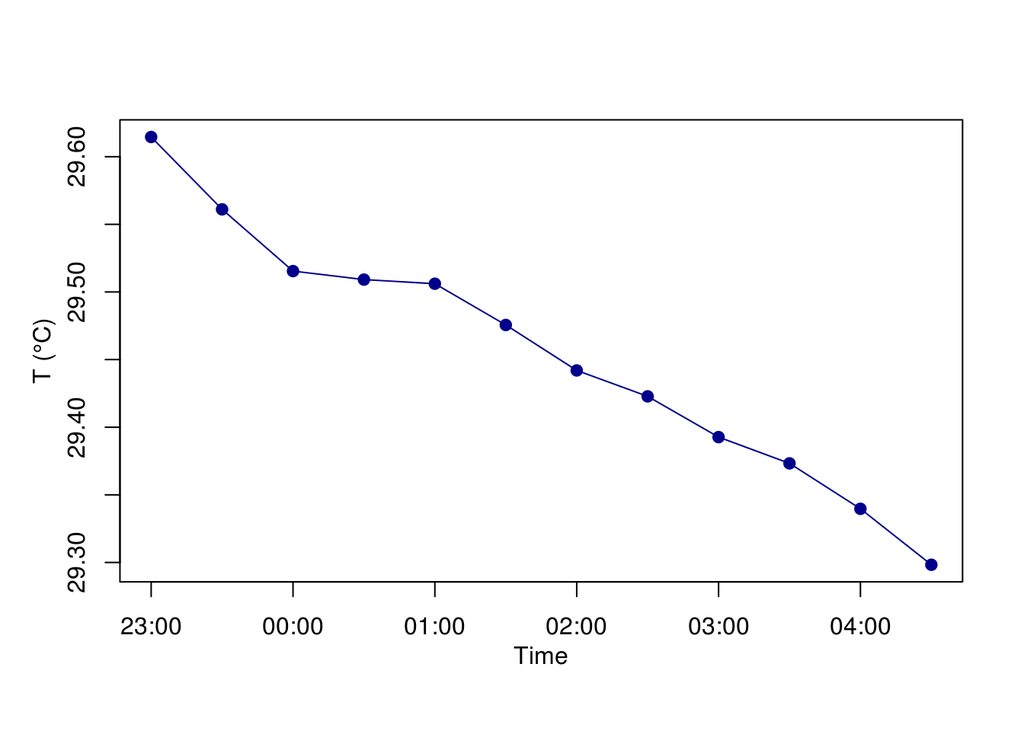

## Rain

The 30-min cumulative rain or precipitation (precip) in mm.

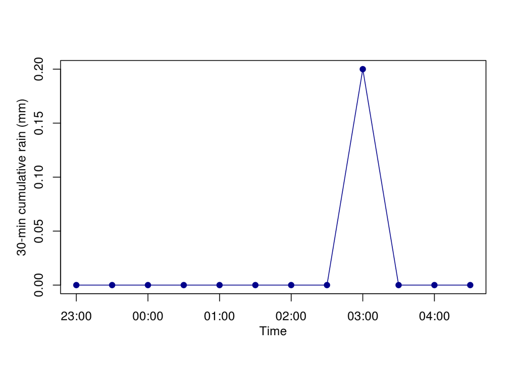